# 200731-practice1

Nougaga

2020 7 31

#### 1. 다음과 같은 벡터 객체를 생성하세요

1. ’R’문자가 5회 반복되도록 하여 벡터 변수 vec1 생성

```r
(vec1 <- rep('R',5))
```

```
## [1] "R" "R" "R" "R" "R"
```

2. 1~10까지 3씩 커지는 연속된 정수를 vec2에

```r
(vec2 <- seq(1, 10, by=3))
```

```
## [1]  1  4  7 10
```

3. 1~10까지 3씩 커지는 연속된 정수가 3회 반복되도록 vec3 생성

```r
(vec3 <- rep(seq(1, 10, by=3), 3))
```

```
##  [1]  1  4  7 10  1  4  7 10  1  4  7 10
```

4. vec2, vec3을 포함하는 백터 변수 vec4 만들기

```r
(vec4 <- c(vec2, vec3))
```

```
##  [1]  1  4  7 10  1  4  7 10  1  4  7 10  1  4  7 10
```

5. 25 ~ -15까지 5의 간격으로 seq()이용 벡터 생성

```r
(vec_with_seq <- seq(25, -15, by=-5))
```

```
## [1]  25  20  15  10   5   0  -5 -10 -15
```

6. vec4에서 홀수번째 값들만 선택하여 vec5에 할당

```r
(vec5 <- vec4[c(seq(1,length(vec4),by=2))])
```

```
## [1] 1 7 1 7 1 7 1 7
```

#### 2. 다음과 같은 벡터를 칼럼으로 갖는 user 데이터프레임을 생성하고

#### gender 변수를 이용하여 히스토그램 그려보세요(barplot())

- name : ‘최민수’,‘유관순’,‘이순신’,‘김유신’,‘홍길동’
- age : 55,45,45,53,15
- gender : 1,2,1,1,1
- job : ‘연예인’,‘학생’,‘군인’,‘직장인’,‘무직’
- sat : 3,4,2,5,5
- grade : ‘C’,‘C’,‘A’,‘D’,‘A’
- total : 44.4, 28.5,43.5,NA,27.1

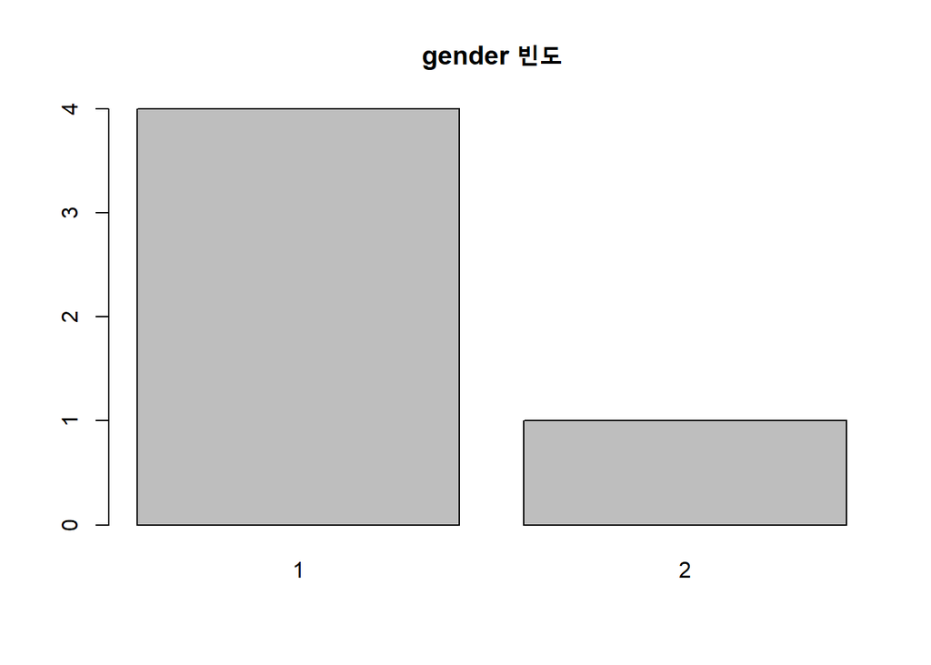

```r
user = data.frame(name=c('최민수','유관순','이순신','김유신','홍길동'),
           age=c(55,45,45,53,15),
           gender=c(1,2,1,1,1),
           job=c('연예인','학생','군인','직장인','무직'),
           sat=c(3,4,2,5,5),
           grade=c('C','C','A','D','A'),
           total=c(44.4, 28.5,43.5,NA,27.1))
user$gender <- as.factor(user$gender)
barplot(table(user$gender), main="gender 빈도")
```

#### 3. 아래의 데이터로 데이터프레임 생성 후,

#### apply()함수를 적용하여 행/열 방향으로 조건에 맞게 통계량을 구해보세요

- kor : 90,85,90
- eng : 70,85,75
- mat : 86,92,88

```r
score = data.frame(kor=c(90,85,90),
                   eng=c(70,85,75),
                   mat=c(86,92,88))
```

조건1) 행/열 방향으로 각각 max() 적용, 최대값 구하기

```r
apply(score, 1, max)  # 행 기준
```

```
## [1] 90 92 90
```

```r
apply(score, 2, max)  # 열 기준
```

```
## kor eng mat
##  90  85  92
```

조건2) 행/열 방향 mean() 적용 평균을 구하여 소수점 2자리까지 표현하세요(셋째자리에서 반올림)

```r
round(apply(score, 1, mean),2)  # 행 기준
```

```
## [1] 82.00 87.33 84.33
```

```r
round(apply(score, 2, mean),2)  # 열 기준
```

```
##   kor   eng   mat
## 88.33 76.67 88.67
```